# 52414 - lab 1

52414

4/4/2020

# *Lab 1: Basic Data Wrangling*

**Contents**:  
* Q0) Submission Instructions  
* Q1) Data Preparation and Manipulation  
* Q2) Analysis of Daily New Corona Cases and Deaths  
* Q3) Preparing and Analyzing the World Bank Data * Q4) Joining the Datasets  
* Q5) Open Question

### Submission Instructions

This lab will be submitted in pairs using GitHub (if you don’t have a pair, please contact us).  
Please follow the steps in the [GitHub-Classroom Lab 1](https://classroom.github.com/g/oSZNtHq4) to create your group’s Lab 1 repository.  
**Important: your team’s name must be `FamilyName1_Name1_and_FamilyName2_Name2`**.  
You can collaborate with your partner using the git environment; You can either make commits straight to master, or create individual branches (recommended). However, once done, be sure to merge your branches to master - you will be graded using the most recent master version - your last push and merge before the deadline.  
**Please do not open/review other peoples’ repositories - we will be notified by GitHub if you do.**

Your final push should include this Rmd file (with your answers) together with the html file that is outputted automatically by knitr when you knit the Rmd. Anything else will be disregarded. In addition, please adhere to the following file format:  
`Lab_2_FamilyName1_Name1_and_FamilyName2_Name2.Rmd/html`

For plots and graphs, make sure you add proper titles, labels, and legends/colors (if you have more than 1 variable on the y-axes). Your plots should clearly convey the information you are trying to communicate.  
Please write your code in a clear and concise way, with an emphasis on reproducibility. Use markdown to provide explanations before/after the code blocks.

## A Deeper Dive Into John’s Hopkins Corona Database

The John’s Hopkins Novel Corona Virus (COVID-19) epidemiological data is compiled by the Johns Hopkins University Center for Systems Science and Engineering (JHU CCSE) from various sources.  
The dataset contains data since 22nd of January 2020. For the data and more information about it, please visit [here](https://data.humdata.org/dataset/novel-coronavirus-2019-ncov-cases).

In this lab you will pick up where we left in lecture 2 and analyze the Corona cases and deaths data.

### Q1

### Data Preparation and Manipulation

(25 points)

1. We first prepare and aggregate the data.
1. First, load the `Corona Confirmed Cases Narrow`, the `Corona Confirmed Deaths Narrow`, and the `Corona Confirmed Recovered Narrow` datasets directly from the John’s Hopkins website.  
   The type of the `Date` variable should be date type. (2 pts)
2. Create new data-frames named `cases.agg`, `deaths.agg`, and `recovered.agg` which aggregate the `sum` of Corona cases, deaths, and recovered respectively over the different countries’ provinces. To do this, aggregate `Value` using only the country and date features, ignoring all other features (similarly to what has been shown in `lecture 2`).  
   To achieve the aggregation use the `aggregate` function. In addition, order the data-frame first by Country and then by Date (increasing order). The columns of each of the two resulting data-frames should be `Country.Region, Date, Value`. (5pts)
3. Repeat (b) using `tidyverse` and the pipe. Show that the outputs from the two methods are the same. (5pts)
4. Using the last day of March as a reference, create a single stacked bar-plot that visualizes the top 10 countries in terms of their Corona cases, and their respected Corona deaths and recovered cases stacked on top of the current sick people in three different colors (each stack should add up to total cases). Make sure that the first stack shows the number of confirmed Corona sick people (`sick = cases - deaths - recovered`). Each stacked bar should represent a country. Please use the barplot base R function to create this plot. I recommend everyone to read the help documentation for barplot ; go over the expected input, and the different parameters. What is the biggest issue with the information presented in this plot? (13pts)

```r
cases<- read.csv(url("https://data.humdata.org/hxlproxy/data/download/time_series_covid19_confirmed_global_narrow.csv?dest=data_edit&filter01=merge&merge-url01=https%3A%2F%2Fdocs.google.com%2Fspreadsheets%2Fd%2Fe%2F2PACX-1vTglKQRXpkKSErDiWG6ycqEth32MY0reMuVGhaslImLjfuLU0EUgyyu2e-3vKDArjqGX7dXEBV8FJ4f%2Fpub%3Fgid%3D1326629740%26single%3Dtrue%26output%3Dcsv&merge-keys01=%23country%2Bname&merge-tags01=%23country%2Bcode%2C%23region%2Bmain%2Bcode%2C%23region%2Bsub%2Bcode%2C%23region%2Bintermediate%2Bcode&filter02=merge&merge-url02=https%3A%2F%2Fdocs.google.com%2Fspreadsheets%2Fd%2Fe%2F2PACX-1vTglKQRXpkKSErDiWG6ycqEth32MY0reMuVGhaslImLjfuLU0EUgyyu2e-3vKDArjqGX7dXEBV8FJ4f%2Fpub%3Fgid%3D398158223%26single%3Dtrue%26output%3Dcsv&merge-keys02=%23adm1%2Bname&merge-tags02=%23country%2Bcode%2C%23region%2Bmain%2Bcode%2C%23region%2Bsub%2Bcode%2C%23region%2Bintermediate%2Bcode&merge-replace02=on&merge-overwrite02=on&filter03=explode&explode-header-att03=date&explode-value-att03=value&filter04=rename&rename-oldtag04=%23affected%2Bdate&rename-newtag04=%23date&rename-header04=Date&filter05=rename&rename-oldtag05=%23affected%2Bvalue&rename-newtag05=%23affected%2Binfected%2Bvalue%2Bnum&rename-header05=Value&filter06=clean&clean-date-tags06=%23date&filter07=sort&sort-tags07=%23date&sort-reverse07=on&filter08=sort&sort-tags08=%23country%2Bname%2C%23adm1%2Bname&tagger-match-all=on&tagger-default-tag=%23affected%2Blabel&tagger-01-header=province%2Fstate&tagger-01-tag=%23adm1%2Bname&tagger-02-header=country%2Fregion&tagger-02-tag=%23country%2Bname&tagger-03-header=lat&tagger-03-tag=%23geo%2Blat&tagger-04-header=long&tagger-04-tag=%23geo%2Blon&header-row=1&url=https%3A%2F%2Fraw.githubusercontent.com%2FCSSEGISandData%2FCOVID-19%2Fmaster%2Fcsse_covid_19_data%2Fcsse_covid_19_time_series%2Ftime_series_covid19_confirmed_global.csv"),comment.char = '#')
recoverd<- read.csv(url("https://data.humdata.org/hxlproxy/data/download/time_series_covid19_deaths_global_narrow.csv?dest=data_edit&filter01=merge&merge-url01=https%3A%2F%2Fdocs.google.com%2Fspreadsheets%2Fd%2Fe%2F2PACX-1vTglKQRXpkKSErDiWG6ycqEth32MY0reMuVGhaslImLjfuLU0EUgyyu2e-3vKDArjqGX7dXEBV8FJ4f%2Fpub%3Fgid%3D1326629740%26single%3Dtrue%26output%3Dcsv&merge-keys01=%23country%2Bname&merge-tags01=%23country%2Bcode%2C%23region%2Bmain%2Bcode%2C%23region%2Bsub%2Bcode%2C%23region%2Bintermediate%2Bcode&filter02=merge&merge-url02=https%3A%2F%2Fdocs.google.com%2Fspreadsheets%2Fd%2Fe%2F2PACX-1vTglKQRXpkKSErDiWG6ycqEth32MY0reMuVGhaslImLjfuLU0EUgyyu2e-3vKDArjqGX7dXEBV8FJ4f%2Fpub%3Fgid%3D398158223%26single%3Dtrue%26output%3Dcsv&merge-keys02=%23adm1%2Bname&merge-tags02=%23country%2Bcode%2C%23region%2Bmain%2Bcode%2C%23region%2Bsub%2Bcode%2C%23region%2Bintermediate%2Bcode&merge-replace02=on&merge-overwrite02=on&filter03=explode&explode-header-att03=date&explode-value-att03=value&filter04=rename&rename-oldtag04=%23affected%2Bdate&rename-newtag04=%23date&rename-header04=Date&filter05=rename&rename-oldtag05=%23affected%2Bvalue&rename-newtag05=%23affected%2Binfected%2Bvalue%2Bnum&rename-header05=Value&filter06=clean&clean-date-tags06=%23date&filter07=sort&sort-tags07=%23date&sort-reverse07=on&filter08=sort&sort-tags08=%23country%2Bname%2C%23adm1%2Bname&tagger-match-all=on&tagger-default-tag=%23affected%2Blabel&tagger-01-header=province%2Fstate&tagger-01-tag=%23adm1%2Bname&tagger-02-header=country%2Fregion&tagger-02-tag=%23country%2Bname&tagger-03-header=lat&tagger-03-tag=%23geo%2Blat&tagger-04-header=long&tagger-04-tag=%23geo%2Blon&header-row=1&url=https%3A%2F%2Fraw.githubusercontent.com%2FCSSEGISandData%2FCOVID-19%2Fmaster%2Fcsse_covid_19_data%2Fcsse_covid_19_time_series%2Ftime_series_covid19_deaths_global.csv"),comment.char = '#')
dethes<- read.csv(url("https://data.humdata.org/hxlproxy/data/download/time_series_covid19_recovered_global_narrow.csv?dest=data_edit&filter01=merge&merge-url01=https%3A%2F%2Fdocs.google.com%2Fspreadsheets%2Fd%2Fe%2F2PACX-1vTglKQRXpkKSErDiWG6ycqEth32MY0reMuVGhaslImLjfuLU0EUgyyu2e-3vKDArjqGX7dXEBV8FJ4f%2Fpub%3Fgid%3D1326629740%26single%3Dtrue%26output%3Dcsv&merge-keys01=%23country%2Bname&merge-tags01=%23country%2Bcode%2C%23region%2Bmain%2Bcode%2C%23region%2Bsub%2Bcode%2C%23region%2Bintermediate%2Bcode&filter02=merge&merge-url02=https%3A%2F%2Fdocs.google.com%2Fspreadsheets%2Fd%2Fe%2F2PACX-1vTglKQRXpkKSErDiWG6ycqEth32MY0reMuVGhaslImLjfuLU0EUgyyu2e-3vKDArjqGX7dXEBV8FJ4f%2Fpub%3Fgid%3D398158223%26single%3Dtrue%26output%3Dcsv&merge-keys02=%23adm1%2Bname&merge-tags02=%23country%2Bcode%2C%23region%2Bmain%2Bcode%2C%23region%2Bsub%2Bcode%2C%23region%2Bintermediate%2Bcode&merge-replace02=on&merge-overwrite02=on&filter03=explode&explode-header-att03=date&explode-value-att03=value&filter04=rename&rename-oldtag04=%23affected%2Bdate&rename-newtag04=%23date&rename-header04=Date&filter05=rename&rename-oldtag05=%23affected%2Bvalue&rename-newtag05=%23affected%2Binfected%2Bvalue%2Bnum&rename-header05=Value&filter06=clean&clean-date-tags06=%23date&filter07=sort&sort-tags07=%23date&sort-reverse07=on&filter08=sort&sort-tags08=%23country%2Bname%2C%23adm1%2Bname&tagger-match-all=on&tagger-default-tag=%23affected%2Blabel&tagger-01-header=province%2Fstate&tagger-01-tag=%23adm1%2Bname&tagger-02-header=country%2Fregion&tagger-02-tag=%23country%2Bname&tagger-03-header=lat&tagger-03-tag=%23geo%2Blat&tagger-04-header=long&tagger-04-tag=%23geo%2Blon&header-row=1&url=https%3A%2F%2Fraw.githubusercontent.com%2FCSSEGISandData%2FCOVID-19%2Fmaster%2Fcsse_covid_19_data%2Fcsse_covid_19_time_series%2Ftime_series_covid19_recovered_global.csv"),comment.char = '#')

#b
cases$Date=as.Date(cases$Date)
cases.agg1<-aggregate(Value ~ Country.Region+Date,data=cases,FUN=sum)
cases.agg<- cases.agg1[order(cases.agg1$Country.Region,cases.agg1$Date),]

dethes$Date=as.Date(dethes$Date)
deaths.agg1<-aggregate(Value ~ Country.Region+Date,data=dethes,FUN=sum)
deaths.agg<- deaths.agg1[order(deaths.agg1$Country.Region,deaths.agg1$Date),]

recoverd$Date=as.Date(recoverd$Date)
recovered.agg1<-aggregate(Value ~ Country.Region+Date,data=recoverd,FUN=sum)
recovered.agg<- recovered.agg1[order(recovered.agg1$Country.Region,recovered.agg1$Date),]

#c
acases<- cases %>% group_by(Country.Region,Date) %>% summarise(casesValue=sum(Value))
scases<-acases %>% inner_join (cases.agg,by=c("Country.Region","Date"),by.x="casesValue",by.y="value")

 adeaths<- dethes %>% group_by(Country.Region,Date) %>% summarise(deathsValue=sum(Value))
sdeaths<-adeaths%>% inner_join (deaths.agg,by=c("Country.Region","Date"),by.x="deathsValue",by.y="value")
head(deaths.agg)
```

```
##     Country.Region       Date Value
## 1      Afghanistan 2020-01-22     0
## 188    Afghanistan 2020-01-23     0
## 375    Afghanistan 2020-01-24     0
## 562    Afghanistan 2020-01-25     0
## 749    Afghanistan 2020-01-26     0
## 936    Afghanistan 2020-01-27     0
```

```r
arecovered<- recoverd %>% group_by(Country.Region,Date) %>% summarise(recoveredValue=sum(Value))
srecovered<-arecovered %>% inner_join (recovered.agg,by=c("Country.Region","Date"),by.x="recoveredValue",by.y="value")

#d
head(adeaths)
```

```
## # A tibble: 6 x 3
## # Groups:   Country.Region [1]
##   Country.Region Date       deathsValue
##   <fct>          <date>           <int>
## 1 Afghanistan    2020-01-22           0
## 2 Afghanistan    2020-01-23           0
## 3 Afghanistan    2020-01-24           0
## 4 Afghanistan    2020-01-25           0
## 5 Afghanistan    2020-01-26           0
## 6 Afghanistan    2020-01-27           0
```

```r
head(arecovered)
```

```
## # A tibble: 6 x 3
## # Groups:   Country.Region [1]
##   Country.Region Date       recoveredValue
##   <fct>          <date>              <int>
## 1 Afghanistan    2020-01-22              0
## 2 Afghanistan    2020-01-23              0
## 3 Afghanistan    2020-01-24              0
## 4 Afghanistan    2020-01-25              0
## 5 Afghanistan    2020-01-26              0
## 6 Afghanistan    2020-01-27              0
```

```r
adeaths$Date=as.Date(adeaths$Date)
arecovered$Date=as.Date(arecovered$Date)
all<- acases %>% inner_join(adeaths,by=c("Country.Region","Date"))%>% inner_join(arecovered , by=c("Country.Region","Date"))

all<-mutate(all,sickvalue = casesValue - deathsValue - recoveredValue )
head(all,10)
```

```
## # A tibble: 10 x 6
## # Groups:   Country.Region [1]
##    Country.Region Date       casesValue deathsValue recoveredValue sickvalue
##    <fct>          <date>          <int>       <int>          <int>     <int>
##  1 Afghanistan    2020-01-22          0           0              0         0
##  2 Afghanistan    2020-01-23          0           0              0         0
##  3 Afghanistan    2020-01-24          0           0              0         0
##  4 Afghanistan    2020-01-25          0           0              0         0
##  5 Afghanistan    2020-01-26          0           0              0         0
##  6 Afghanistan    2020-01-27          0           0              0         0
##  7 Afghanistan    2020-01-28          0           0              0         0
##  8 Afghanistan    2020-01-29          0           0              0         0
##  9 Afghanistan    2020-01-30          0           0              0         0
## 10 Afghanistan    2020-01-31          0           0              0         0
```

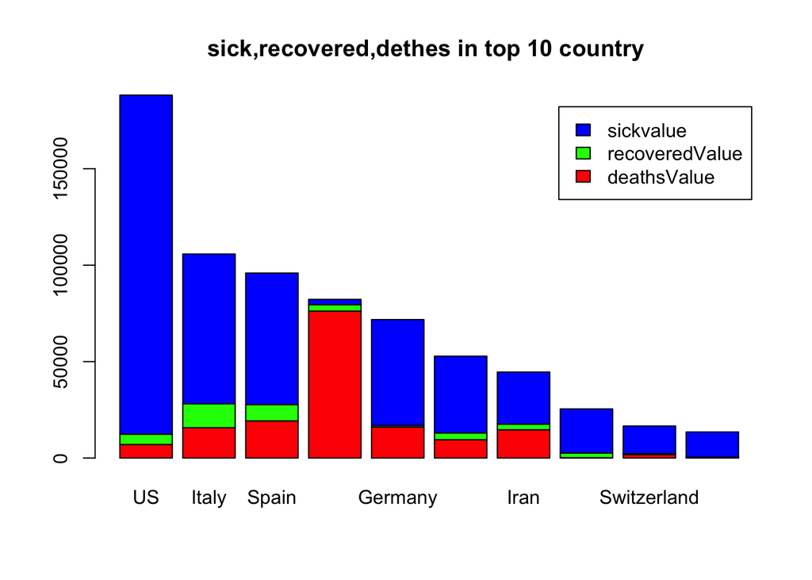

```r
allmarch <- all[which(all$Date == "2020-03-31"),]
allmarchorder<-allmarch[order(allmarch$casesValue,decreasing =TRUE ),]
marchtop10<-allmarchorder[1:10,]
marchtop10<-marchtop10[,c(1,4:6)]
remarchtop10<-marchtop10 %>% select (Country.Region ,sickvalue,deathsValue,recoveredValue)
marchtop10.t<-t(marchtop10)
colnames(marchtop10.t)<-marchtop10$Country.Region
marchtop10.t<-marchtop10.t[c(2:4),]
barplot(marchtop10.t,main="sick,recovered,dethes in top 10 country ",legend=rownames(marchtop10.t),col=c("red","green","blue"))
```

**Solution:**

### Q2

### Analysis of Daily New Corona Cases and Deaths

20 points

The two datasets (Corona Cases and Deaths) register the value of cases and deaths, respectively, as a cumulative sum for each day. In this question we would like to understand the daily differences between consecutive days.

1. Add a new column named `Diff` to both the `cases.agg` and the `deaths.agg` data-frames. This new column should register the daily `Value` difference for each country. In other words, the `Diff` column shows how many new cases/deaths each country incurs every day. Hint - diff must be per country. (7pts)
2. Find the top 10 instances of country and date combinations with the greatest absolute number of new daily Corona cases and deaths (separately). Print the result in a descriptive format. (5pts)
3. In one figure, plot Italy’s new daily Corona cases AND deaths as a function of Date. Choose the plot type you think that makes the most sense. (3pts)
4. Plot the same graph as in (c), but this time plot the number of new cases on the logarithm scale. What can we learn? (5pts)

**Solution:**

```r
#a
cases.agg<-mutate(cases.agg,diff = 0   )
cases.agg$diff[1]<-cases.agg$Value[1]
i<-1
t<-17390
while (t>i) {
i=i+1
row<-cases.agg[i,]
prevrow<-cases.agg[i-1,]
if(prevrow[1]==row[1]){
newvalue<-row[3]-prevrow[3]
}else{
newvalue<-cases.agg$Value[i]
}
cases.agg$diff[i]<-newvalue
}


deaths.agg<-mutate(deaths.agg,diff = 0   )
deaths.agg$diff[1]<-deaths.agg$Value[1]
i<-1
t<-17390
while (t>i) {
i=i+1
row<-deaths.agg[i,]
prevrow<-deaths.agg[i-1,]
if(prevrow[1]==row[1]){
newvalue=row[3]-prevrow[3]
}else{
newvalue=deaths.agg$Value[i]
}
deaths.agg$diff[i]=newvalue
}
#b
deaths.agg$diff<-as.integer(deaths.agg$diff)
try1<- deaths.agg[order(deaths.agg$diff,decreasing =TRUE),]
print(head(try1,10))
```

```
##       Country.Region       Date  Value  diff
## 2385          Brazil 2020-04-15  14026 10980
## 6678         Germany 2020-04-08  46300 10219
## 8391         Ireland 2020-04-21   9233  9156
## 2389          Brazil 2020-04-19  22130  8104
## 6677         Germany 2020-04-07  36081  7381
## 6694         Germany 2020-04-24 109800  6500
## 8181            Iran 2020-04-11  41947  6482
## 15799          Spain 2020-04-29 108947  6399
## 6687         Germany 2020-04-17  83114  6114
## 6679         Germany 2020-04-09  52407  6107
```

```r
cases.agg$diff<-as.integer(cases.agg$diff)
try2<- cases.agg[order(cases.agg$diff,decreasing =TRUE),]
print(head(try2,10))
```

```
##       Country.Region       Date  Value  diff
## 6282          France 2020-04-12 121712 26849
## 3623           China 2020-02-13  59895 15136
## 6286          France 2020-04-16 146075 12490
## 5294         Ecuador 2020-04-24  22719 11536
## 15764          Spain 2020-03-25  49515  9630
## 15765          Spain 2020-03-26  57786  8271
## 15771          Spain 2020-04-01 104118  8195
## 15770          Spain 2020-03-31  95923  7967
## 15772          Spain 2020-04-02 112065  7947
## 15766          Spain 2020-03-27  65719  7933
```

[figure not shown]

```r
#c
italy<-cases.agg[which(cases.agg$Country.Region =='Italy'),] %>% inner_join (deaths.agg[which(deaths.agg$Country.Region =='Italy'),],by=c("Country.Region","Date"),)

plot(x=italy$Date, y= italy$diff.x,
    main= "italy daily number of sick and deaths",
    xlab= "dates",
    ylab= "daily number",
    col= "blue")
points(x=italy$Date, y= italy$diff.y,
    main= "italy",
    xlab= "dates",
    ylab= "daily number",
    col= "red")
legend("topleft",c("sick","deaths"),fill=c("blue","red"))
```

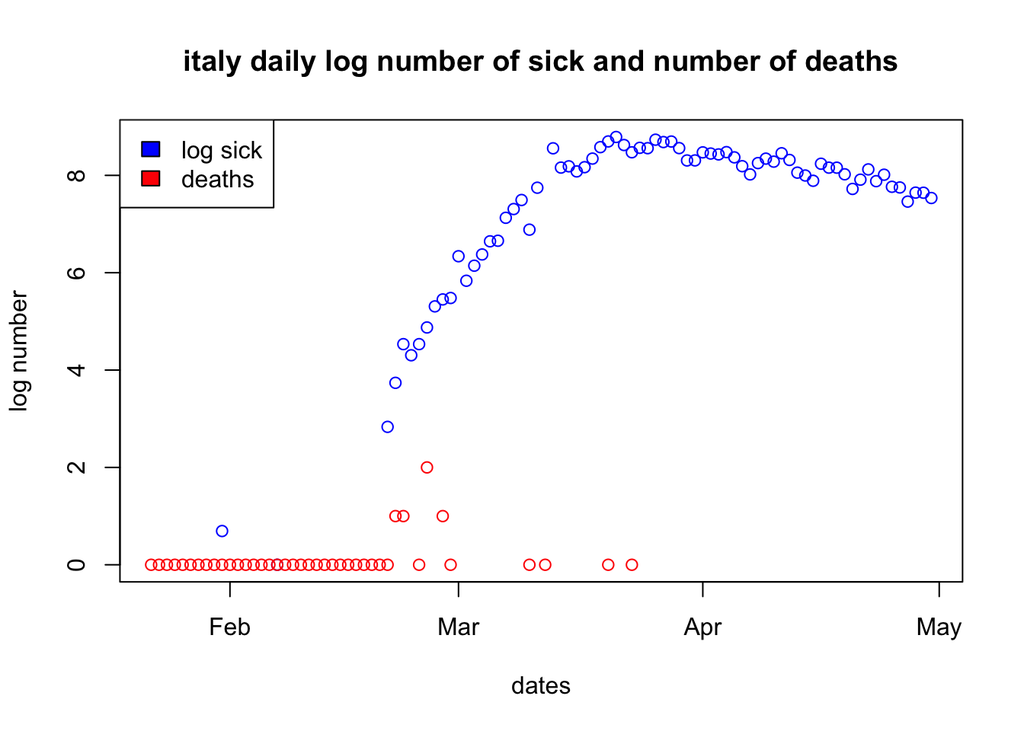

```r
#d
plot(x=italy$Date, y= log(italy$diff.x),
    main= ("italy daily log number of sick and number of deaths"),
    xlab= "dates",
    ylab= "log number",
    col= "blue")
points(x=italy$Date, y= italy$diff.y,
    main= "italy",
    xlab= "dates",
    ylab= "daily number",
    col= "red")
legend("topleft",c("log sick","deaths"),fill=c("blue","red"))
```

### Q3

### Preparing and Analyzing the World Bank Data

25 points

1. Rename the columns of `eco_data`: `country,S_country,feature,feature_code,Y2018V,Y2019V`. (2pts)
2. Create a new `eco` data-frame whose dimensions are $N \times 11$, where `N` is the number of countries. The first column should include the names of the countries in `eco_data.`  
   The rest of the columns should be the features with their respective values in `eco_data` for each country from 2018. Print the head of the new data-frame.(8pts).  
   In other words, in this question you are asked to create a new eco data-frame whose dimensions are $N \times 11$, where N is the number of countries (the first column should include the names of the countries in `eco_data`). The rest of the columns should be the features with their respective values in eco_data for each country from 2018. Print the head of the new data-frame. You may delete rows with NA as a country value only.
3. Select and rename the following columns: `country` as country, `GDP(US currency)` as GDP, `Population ages 65 and above (% of total population)` as pop65, `Population in the largest city (% of urban population)` as pop_city_ratio, `Population, total` as pop_total columns . (2pts)
4. Show a table of the five countries with the highest per capita GDP in 2018.  
   Next (considering all countries), plot the % of population over 65 vs. log of GDP per capita in 2018, after excluding the 10% countries with the lowest GDP per capita. Using `lm` and `abline`, add a regression line to the plot. What is your conclusion? (13 pts)

**Solution:**

```r
#loading the `eco_data`:
eco_data <- read.csv(url("https://raw.githubusercontent.com/DataScienceHU/DataAnalysisR_2020/master/data/economic_data.csv"))

eco_data <- rename(eco_data, country = Country.Name )
eco_data <- rename(eco_data, S_country = Country.Code )
eco_data <- rename(eco_data, feature = Series.Name )
eco_data <- rename(eco_data, feature_code = Series.Code )
eco_data <- rename(eco_data, Y2018V = X2018..YR2018. )
eco_data <- rename(eco_data, Y2019V = X2019..YR2019. )


eco_data_new <- eco_data[c(1:2640) , c(1,3,5) ]
eco_data_new$Y2018V <- as.numeric(as.character(eco_data_new$Y2018V))
eco <- dcast(eco_data_new, country~feature, value.var ="Y2018V")
#c
eco <- rename(eco, country = country )
eco <- rename(eco, GDP = `GDP (current US$)`)
eco <- rename(eco, pop65 = `Population ages 65 and above (% of total population)`)
eco <- rename(eco, pop_city_ratio = `Population in the largest city (% of urban population)`)
eco <- rename(eco, pop_total = `Population, total`)

#d
eco <- eco %>% mutate(GDP_per_capita = as.numeric(GDP / pop_total))
eco_data_new <- eco[order(eco$GDP_per_capita, decreasing = TRUE),]
head(eco_data_new,5)
```

```
##              country GDP (constant LCU)          GDP
## 163           Monaco       5.720647e+09   7184844193
## 145       Luxembourg       5.715260e+10  70885325883
## 146 Macao SAR, China       4.294970e+11  55084050790
## 234      Switzerland       6.961395e+11 705140354166
## 181           Norway       3.259053e+12 434166615432
##     GDP, PPP (current international $)
## 163                                 NA
## 145                        68878323882
## 146                        78254752438
## 234                       579643931032
## 181                       348145261704
##     Government expenditure on education, total (% of GDP)    pop65
## 163                                                    NA       NA
## 145                                                    NA 14.18315
```

[output cut: 33 more lines]

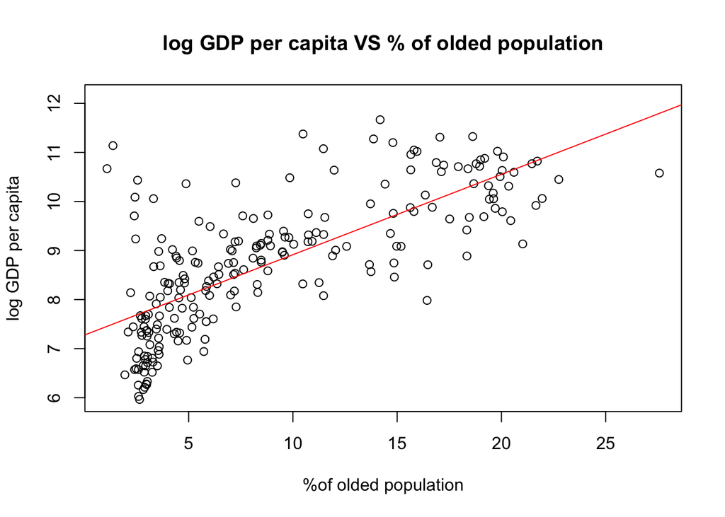

```r
eco_data_new <- head(eco_data_new , as.integer(264*0.9))
plot(x= eco_data_new$pop65,
     y= log(eco_data_new$GDP_per_capita) ,
     col = "black" ,
     main = "log GDP per capita VS % of olded population" ,
     ylab = "log GDP per capita" ,
     xlab = "%of olded population")
abline(lm(log(eco_data_new$GDP_per_capita) ~ eco_data_new$pop65, data = eco_data_new) ,col="red")
```

### Q4

### Joining the Datasets

20 points

1. Join the `deaths.agg`, `cases.agg`, and `recovered.agg` into one data-frame called `corona`.(5pts)
2. Join the `corona` and `eco` data-frames in a way that will keep the most information regarding the data (but not full join).  
   Make sure that no essential data is thrown away (show this). (3pts)
3. Create new columns of normalized `cases`, `deaths`, and `recovered` so they will show the number of cases per 100,000 people for each country.  
   Using the last day of March as a reference, create a single stacked bar plot that visualizes the top 10 countries in terms of normalized Corona cases, and their respected normalized Corona deaths and recovered, as done in Q1.  
   how is it different from the graph before normalization? (5pts)
4. Using the last day of March as a reference, create a scatter-plot of normalized deaths and cases vs. `pop65`. Limit the plot to show only countries with 15% or more of `pop65`.  
   In addition, color the outliers( pop65>24, norm100K_deaths>15) in that plot in red and add to the plot their country names (7pts)

**Solution:**

```r
#a
corona<-cases.agg %>% inner_join (deaths.agg,by=c("Country.Region","Date"),) %>% rename(diffcases=diff.x , diffdeaths= diff.y , valuecases=Value.x ,valuedeaths=Value.y)
corona<-corona %>% inner_join (recovered.agg,by=c("Country.Region","Date"),)

#b
eco <- rename(eco, Country.Region = country )
eco$Country.Region<-as.character(eco$Country.Region)
corona$Country.Region<-as.character(corona$Country.Region)
ecocorona<-corona %>% left_join(eco,by="Country.Region")

#c
ecocorona<- ecocorona %>% mutate(sdcases=as.numeric(ecocorona$valuecases*100000/ecocorona$pop_total),sdeaths=as.numeric(ecocorona$valuedeaths*100000/ecocorona$pop_total),sdrecovered=as.numeric(ecocorona$Value*100000/ecocorona$pop_total))

ecocoronamarch <- ecocorona[which(ecocorona$Date == "2020-03-31"),]


chooseorder<-ecocoronamarch[order(ecocoronamarch$sdcases,decreasing =TRUE ),]
sdmarchtop10<-chooseorder[1:10,]
sdmarchtop10<-sdmarchtop10[,c(1,19:21)]
head(sdmarchtop10)
```

```
##       Country.Region  sdcases  sdeaths sdrecovered
## 14470     San Marino 698.5349 38.47861  76.9572295
## 370          Andorra 488.2736 12.98600  15.5832013
## 10270     Luxembourg 358.3840 13.16378   3.7845878
## 7870         Iceland 321.0078 55.99959   0.5656525
## 15770          Spain 205.2982 41.21887  18.1149847
## 16270    Switzerland 194.9735 21.40540   5.0842226
```

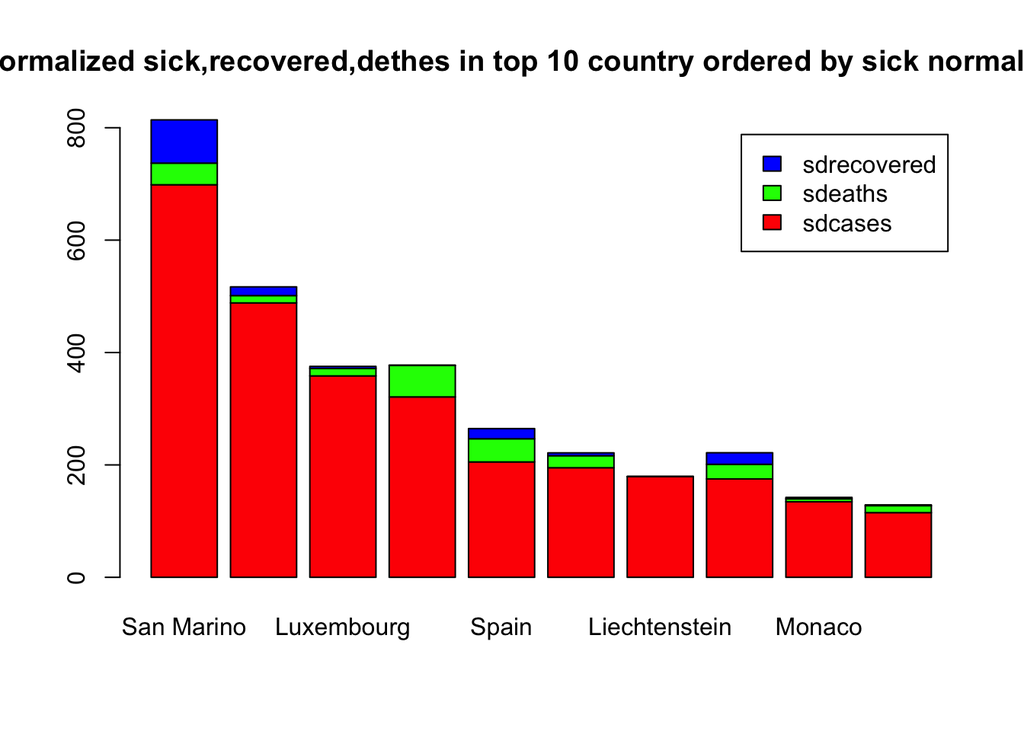

```r
sdremarchtop10<-sdmarchtop10 %>% select (Country.Region ,sdcases,sdeaths,sdrecovered)
sdmarchtop10.t<-t(sdremarchtop10)
colnames(sdmarchtop10.t)<-sdremarchtop10$Country.Region
sdmarchtop10.t<-sdmarchtop10.t[c(2:4),]
barplot(sdmarchtop10.t,main=" normalized sick,recovered,dethes in top 10 country ordered by sick normaliztion ",legend=rownames(sdmarchtop10.t),col=c("red","green","blue"))
```

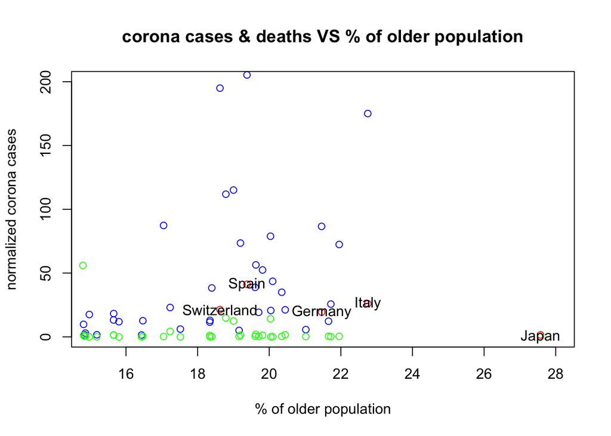

```r
#d
helv<-which(chooseorder$sdeaths>15 & chooseorder$pop65>15 | chooseorder$pop65>24)
plot(x=chooseorder$pop65, y= chooseorder$sdcases,
    main= "corona cases & deaths VS % of older population",
    xlab= "% of older population",
    ylab= "normalized corona cases",
    xlim=c(15,28),
    ylim=c(0,200),
    col= ifelse (chooseorder$pop65<24,"blue","red"))
points(x=chooseorder$pop65, y= chooseorder$sdeaths, main= "italy",
    xlab= "% of older population",
    ylab= "normalized corona deaths",
    xlim=c(15,28),
    ylim=c(0,200),
    col = ifelse(chooseorder$sdeaths <= 15 | chooseorder$pop65<15,'green','red'))
text(chooseorder$pop65[helv],chooseorder$sdeaths[helv],labels=chooseorder$Country.Region[helv])
```

```r
mo<- chooseorder$pop65[helv]
```

### Q5

### Open Question

10 points

Write an interesting research question regarding the Corona outbreak and then follow the steps to answer it using tables and plots. You can use the loaded datasets or any other dataset you find as long as you add the data file to your `lab1` repository so it can be loaded directly from a `url` (e.g. the World Bank). This question will be graded based on creativity, originality, and the novelty of the analysis.

**Solution:**

This database is taken from the Israeli Ministry of Health. It includes data regarding people who recoverd from Coronavirus, such as age groups, gender, how many days passed from the first positive test to the negetive one, and the number of tests they went through in total. We chose to research the recovery time, and whether it depends on age or gender. In order to study it, we made 3 boxplots: one for the female group, one for the male group and the third showing the total for both together. The axes show the number of days which passed between the positive to the negetive test by age groups. As we can see, the plots show that the median is about the same for all age groups, which brings us to the conclusion that the healing period length does not distinctly depends on age. Notice that the variance of time for recovery is smaller in the male plot for all age groups.

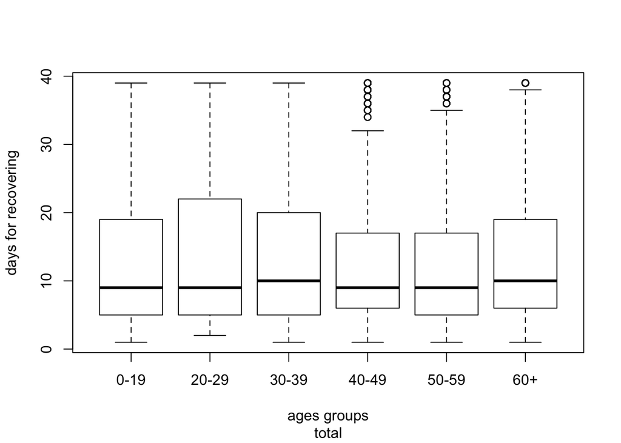

```r
tests_data <- read.csv('corona_recovered.csv')
tests_data$days_between_pos_and_neg <- as.numeric(tests_data$days_between_pos_and_neg)
tests_data <- subset(tests_data, days_between_pos_and_neg < 40 )
tests_data <- tests_data[order(tests_data$days_between_pos_and_neg, decreasing = TRUE),]

plot(tests_data$days_between_pos_and_neg ~ tests_data$age_group,
        sub = "total",
        xlab = "ages groups",
        ylab = "days for recovering")
```

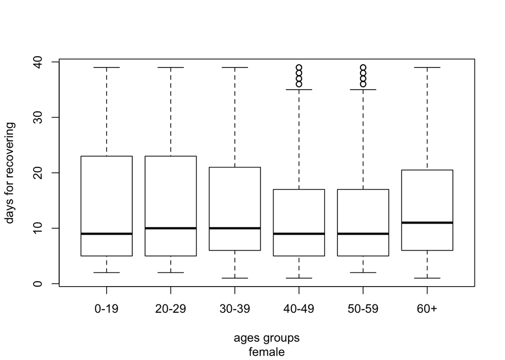

```r
female_tests <- subset(tests_data, gender == "female")
plot(female_tests$days_between_pos_and_neg ~ female_tests$age_group,
        sub = "female",
        xlab = "ages groups",
        ylab = "days for recovering")
```

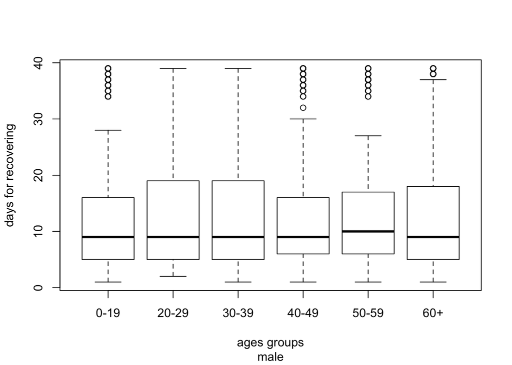

```r
male_tests <- subset(tests_data, gender == "male")
plot(male_tests$days_between_pos_and_neg ~ male_tests$age_group,
        sub = "male",
        xlab = "ages groups",
        ylab = "days for recovering")
```